# Project 2

2024-10-01

```r
library(tidyverse)
```

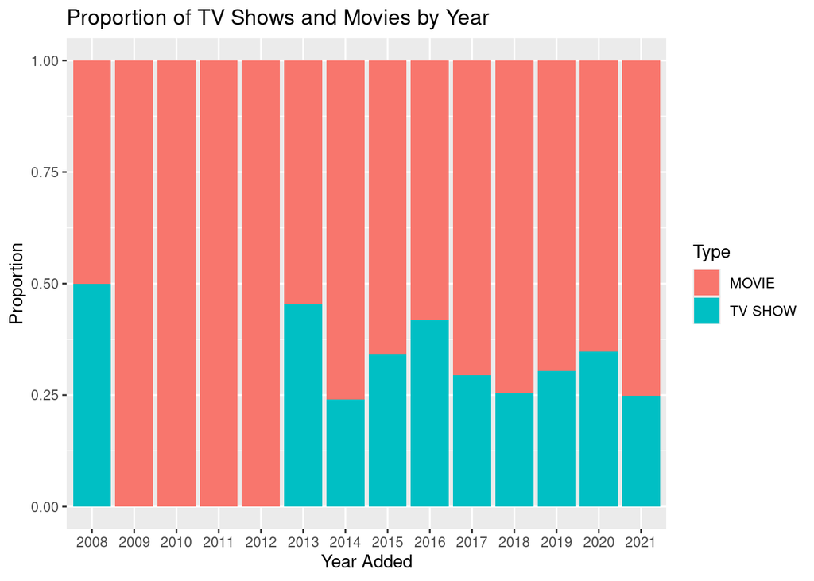

```r
library(ggplot2)
netflix_titles <- readr::read_csv('https://raw.githubusercontent.com/rfordatascience/tidytuesday/master/data/2021/2021-04-20/netflix_titles.csv')
netflix_titles_updated <- netflix_titles |>
  mutate(year_added = str_extract(date_added, "\\d{4}"),
         year_added = str_replace_na(year_added, "Unknown"))|>
  mutate(type = str_to_upper(type))|>

  filter(year_added != "Unknown")


#view(netflix_titles_updated)


proportion_data <- netflix_titles_updated |>
  group_by(year_added, type) |>
  summarise(count = n()) |>
  ungroup() |>
  group_by(year_added) |>
  mutate(proportion = count / sum(count))
#proportion_data



proportion_plot_1 <- ggplot(proportion_data, aes(x = year_added, y = proportion, fill = type)) +
  geom_bar(stat = "identity", position = "stack") +
  labs(title = "Proportion of TV Shows and Movies by Year",
       x = "Year Added",
       y = "Proportion",
       fill = "Type")

proportion_plot_1
```

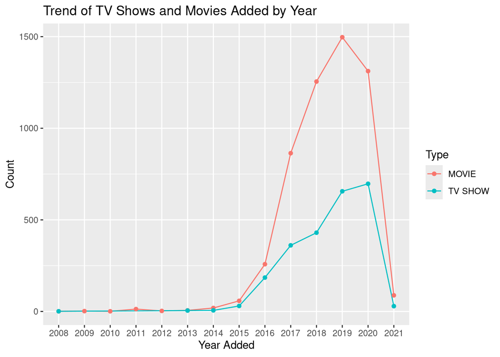

```r
trend_plot <- netflix_titles_updated |>
  count(year_added, type) |>
  ggplot(aes(x = year_added, y = n, color = type, group = type)) +
  geom_line() +
  geom_point() +
  labs(title = "Trend of TV Shows and Movies Added by Year",
       x = "Year Added",
       y = "Count",
       color = "Type")
trend_plot
```

```r
genres <- c("Thriller", "Action", "Dramas", "Romantic", "Horror", "Crime", "Sci-Fi", "Fantasy", "Comedies", "Documentaries", "Kids\' TV")

genre<- netflix_titles_updated|>
  mutate(is_genre = str_detect(listed_in, str_c(genres, collapse = "|")))|>
  mutate(genre_label = str_extract(listed_in, str_c(genres, collapse = "|")))|>
  group_by(year_added, type, genre_label) |>
  summarise(count = n())
```

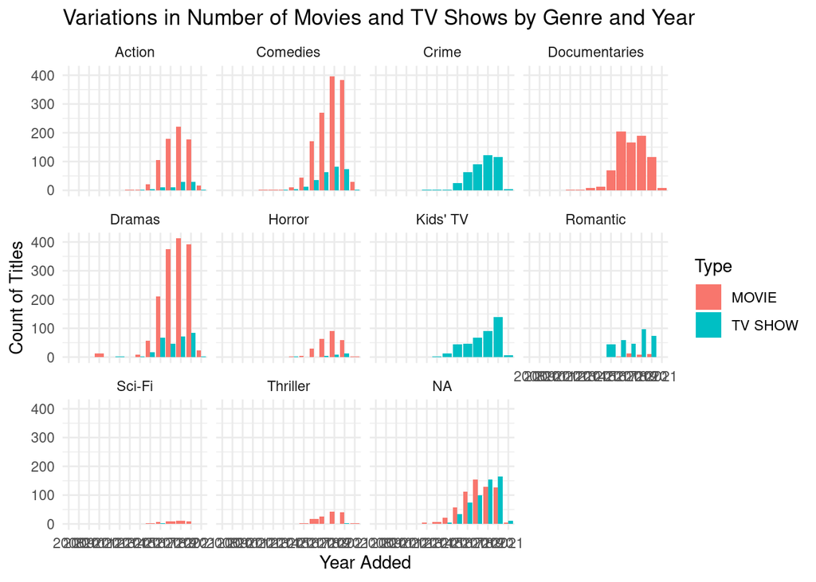

```r
#genre


ggplot(genre, aes(x = year_added, y = count, fill = type)) +
  geom_bar(stat = "identity", position = "dodge") +
  facet_wrap(~ genre_label) +
  labs(title = "Variations in Number of Movies and TV Shows by Genre and Year",
       x = "Year Added",
       y = "Count of Titles",
       fill = "Type")+
       theme_minimal()
```

ANALYSIS

The first plot, “Proportion of TV Shows and Movies by Year”, shows the proportion of TV shows and movies added to Netflix each year. This is a stacked bar chart, where each year is represented by a bar, with segments showing the proportion of TV shows and movies.In the graph, movies tended to dominate the viewing options expecially from 2009 to 2012. Although TV Shows in 2008 had the same as movies. In recent years however,the proportion of TV shows have increased with about 25 percent of viewing options being TV shows.

The second plot, “Trend of TV Shows and Movies Added by Year”, shows the actual counts of TV shows and movies added per year. This is a line plot with different colors representing movies and TV shows. Between 2015 and 2020, they both experienced steep growths however movies added far outweighed TV Shows added

Reference:

https://raw.githubusercontent.com/rfordatascience/tidytuesday/master/data/2021/2021-04-20/netflix_titles.csv

https://github.com/rfordatascience/tidytuesday/blob/master/data/2021/2021-04-20/readme.md